# Traffic patterns from UBER Movement Dataset

# 1 Preparing Datasets

Datasets:

| Dataset | Aggregated travel times between every zone pair in the city |
| --- | --- |
| Time Period | Q1 2018 |
| City | Delhi, Mumbai, Bangalore |
| Source | [Uber Movement](https://movement.uber.com/explore/) |

```r
suppressPackageStartupMessages(library(tidyverse))
new_delhi_wards <- read.csv("Data/uber_delhi_ward_ids.csv", stringsAsFactors = FALSE)
inter_ward_times <- data.table::fread("Data/delhi_hod_times.csv", stringsAsFactors = F)
```

## 1.1 Preparing the distance components

Inter ward distance was calculated through QGIS using the the wards geojson file downloaded from the UBER Movement website for DELHI. Process was:

- To first find the center of each polygon
- To calculate a distance matrix from each polygon center to other for all ploygons

```r
inter_ward_distance <- data.table::fread("Data/spatial/delhi_distance_matrix.csv", stringsAsFactors = F, data.table = FALSE)
```

## 1.2 Merging Distance and Time components

```r
inter_ward_matrix <-
  dplyr::left_join(
    inter_ward_times,
    inter_ward_distance,
    by = c('sourceid' = 'InputID', 'dstid' = 'TargetID')
  )
```

## 1.3 Converting distance to kilometer

```r
inter_ward_matrix$distance_km <- inter_ward_matrix$distance_metre/1000
```

# 2 Hourly Analysis of time taken and distance covered

## 2.1 Time per km ranges at every Hour of the day

The objective of this analysis is to focus on the congestion of vehicular activity on city routes. Since the current dataset from UBER gives us just the travel times, it is importatnt to normlaise it by the distance metric, thus focusing on time taken on covering every km of a route (assumption being that every km takes the equal amount of time, certainly not the case, but this should be good for an EDA) and treating it as a proxy of business of that route.

```r
inter_ward_matrix$time_per_km <- inter_ward_matrix$mean_travel_time/inter_ward_matrix$distance_km
```

Let’s now look at the density plots for time per km at every hour of the day - This will help us see the range of times and check if the flow rate of city traffic is constant at every hour or varies across routes

Excluding the rides done in the same Movement zone, as the distance is not calculated for such cases.

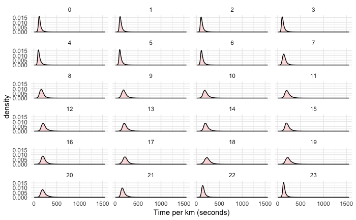

Results:

- There are high peaks from 0-6 hours as the congestion seems to be less at these points, so most rides are able to maintain a good flow rate, 75% of these rides cover a distance of a km in less than *150* seconds
- The peaks turns a bit flat after 7 AM and the width increases, as the congestion increases, so is the variability with time.

## 2.2 Time taken by the majority

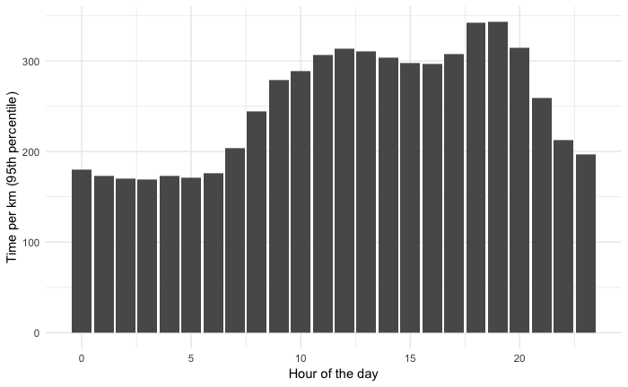

Observations:

Being rush office hours,

- First peak is around 11-13, where TPK (Time per km) is close to 300s
- Second peak is around 17-20 where the TPK goes almost till 350s

## 2.3 How far can you go in an hour

A prominent indicator of congestion in any city is the variation in average speed of vehicles over time. Distance travelled in an hour of time at various times of the day should be a good proxy to determine the flow rates of different routes or cities themselves. Having analysed Delhi’s traffic throughout the day and at diferent routes, lets compare it with other cities i.e Mumbai and Bangalore. For this analysis, we download the data from [UBER Movement](https://movement.uber.com/explore) for these cities for a similar time period i.e. **Q1 2018**. Our objective here is to see how far we can travel in an hour at all hours (0 to 23), the results will help us compare the congestion rates in Delhi with these cities, let’s prepare the data and look at the results.

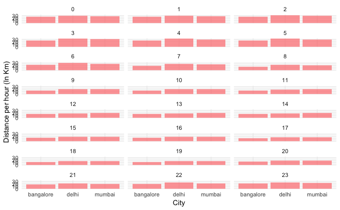

```r
ggplot(hourly_spider, aes(x = city,y = distance_per_hour)) +
  geom_bar(alpha=.6, fill="#FF6666",stat = 'identity') +
  ylab('Distance per hour (In Km)') + xlab('City') +
  facet_wrap(~ hod, nrow=8) + theme_minimal()
```

Observations:

- **Bangalore** looks the most congested of cities at all hours when compared with Delhi and Mumbai
- **Delhi** is the least congested at night and Peak AM hours i.e from 10 PM till 8 AM
- **Mumbai** is the least congested at peak hours i.e from 9 AM till 8 PM

Out of the three cities:

- Maximum you can travel in an hour is **32.8** kms at **3 AM** in Delhi
- Minimum you can travel in an hour is **12.5** kms at **6 PM** in Bangalore

> Yes, Bangalore traffic looks way poor than Delhi or Mumbai.

Till now we were only working with hod(Hour of the day), now lets take the route into consideration as well

# 3 Busiest routes throughout the day (Top 10):

```r
x <- inter_ward_matrix %>% filter(!is.na(time_per_km))%>% group_by(sourceid, dstid) %>%
  summarise(mean_tpk = mean(time_per_km))
x <- dplyr::left_join(x, inter_ward_distance, by = c('sourceid' = 'InputID', 'dstid' = 'TargetID'))
x <- x[order(-x$mean_tpk), ]
x[1:10,c(1,2,3,5)]
```

| sourceid | dstid | mean_tpk | distance_metre |
| --- | --- | --- | --- |
| 285 | 237 | 1143.5897 | 684.0966 |
| 181 | 178 | 867.4034 | 1577.4517 |
| 98 | 99 | 859.3925 | 1156.2363 |
| 49 | 242 | 796.7738 | 2475.2500 |
| 237 | 285 | 783.8726 | 684.0966 |
| 178 | 181 | 729.3997 | 1577.4517 |
| 44 | 242 | 717.3277 | 1951.8423 |
| 99 | 22 | 693.5847 | 492.5558 |
| 78 | 273 | 688.2093 | 634.5768 |
| 242 | 44 | 685.5247 | 1951.8423 |

> Shorter routes will tend to have a greater TPK, as for larger routes this metric gets time to decrease because of more occurrences of light congestion segments as compared to shorter routes.

Let’s look at the same table again but now between routes which are atleast greater than a km.

```r
x <- x[x$distance_metre >= 1000, ]
x <- x[order(-x$mean_tpk), ]
x[1:10,c(1,2,3,5)]
```

| sourceid | dstid | mean_tpk | distance_metre |
| --- | --- | --- | --- |
| 181 | 178 | 867.4034 | 1577.452 |
| 98 | 99 | 859.3925 | 1156.236 |
| 49 | 242 | 796.7738 | 2475.250 |
| 178 | 181 | 729.3997 | 1577.452 |
| 44 | 242 | 717.3277 | 1951.842 |
| 242 | 44 | 685.5247 | 1951.842 |
| 242 | 49 | 677.1793 | 2475.250 |
| 98 | 100 | 668.9962 | 1893.755 |
| 288 | 135 | 657.1294 | 1063.072 |
| 134 | 20 | 652.5728 | 1168.964 |

Observations:

These are actually pretty congested areas -

The satellite view - one of the busiest route (181 - 178) looks like this

[figure not shown]

# 4 Congested Airport rides

The UBER Movement web UI is amazing, its good from a single user perspective, but if a city planner wants to have compare mutiple routes at once, then it can be a bit difficult. You are always tied to a source and a destination for certain analyses, and though the avergae time for every ward from a source can be identified by a map view, the same thing cannot be done for a destination.

Let’s fix our destination at the Delhi Airport Ward (There is no dedicated ward for this, so taking the closest one - Ward No 5 as a proxy) and look at average times (TPK) from every other ward

```r
dst5 <- inter_ward_matrix[inter_ward_matrix$dstid==5,]
dst5 %>% group_by(sourceid) %>% summarise(mean_tpt = mean(time_per_km)) %>% top_n(5, mean_tpt)
```

```
# A tibble: 5 x 2
  sourceid mean_tpt
     <int>    <dbl>
1      102     320.
2      201     410.
3      202     351.
4      285     273.
5      288     272.
```

The results are same as above, short routes having a higher TPK, but the last two sources are interesting.

# 5 Longest Journeys (in terms of time taken to complete) in a city

```r
library(knitr)
inter_ward_matrix[is.na(inter_ward_matrix)] <- ''
inter_ward_matrix %>% top_n(10, mean_travel_time) %>% select(sourceid, dstid, hod, mean_travel_time,distance_km,time_per_km)  %>% arrange(desc(mean_travel_time)) %>% kable()
```

```
| sourceid| dstid| hod| mean_travel_time|distance_km      |time_per_km      |
|--------:|-----:|---:|----------------:|:----------------|:----------------|
|        5|     5|  21|         10107.75|                 |                 |
|      193|   193|  21|          9314.33|                 |                 |
|        3|     3|  21|          9141.33|                 |                 |
|      223|   223|  21|          9111.50|                 |                 |
|       34|    32|  18|          8968.17|32.7232962606117 |274.060715906386 |
|      119|    32|  18|          8690.43|32.9882471123653 |263.440187361228 |
|       89|   173|  18|          8503.17|30.4132457825518 |279.58771848279  |
|       40|    32|  18|          8179.67|30.722681697032  |266.242057925243 |
|      108|   163|  18|          8137.57|26.9138651818746 |302.356051240099 |
|      191|   284|  18|          8094.67|29.0002459934917 |279.124184043702 |
```

These are the routes with the higest travel times in Delhi. Some observations:

# 6 Time deviations on the same route

```r
route_deviations_df <- readRDS("Data/route_devialtions.rds")
route_deviations_df <- route_deviations_df[!is.na(route_deviations_df$route_deviation), ]
summary(route_deviations_df$route_deviation)
```

```
    Min.  1st Qu.   Median     Mean  3rd Qu.     Max.
   1.633  385.871  579.841  592.093  773.665 5305.606
```

The *mean time deviation* for more than 80% rides is close to **13 mins** (820 s)

But the max deviation for a route is more than **5000 s** (almost an hour and 20 mins). This is where we want to focus our analysis on, so let;s find out those 0.5 percentile of routes (if any), where the deviation is more than **30 mins** (1800 s)

```
| route_start| route_end| route_deviation|
|-----------:|---------:|---------------:|
|         133|       133|        5305.606|
|         228|       228|        5080.668|
|         166|       166|        4975.585|
|         264|       264|        4972.658|
|         219|       219|        4953.778|
|         226|       226|        4899.359|
|         121|       121|        4803.214|
|           5|         5|        4732.191|
|         161|       161|        4726.952|
|          12|        12|        4603.527|
```

So, there are a total of **111** such routes. Let’s see if we could find some patterns here:

- Looking at the dataset for the route with most deviation(133), we found that there are only **2** rows in the base dataset, which means that the data is available for only a coupe of hours. This won’t be a fair comparison with other routes where the data is avialable for all 24 hours. So ;et’s remove them from this dataset and look at these observartions again

```r
number_instances <-
  inter_ward_matrix %>% group_by(sourceid, dstid) %>% summarise(total_hod = length(hod))

  route_deviations_df <-
  dplyr::left_join(
  route_deviations_df,
  number_instances,
  by = c('route_start' = 'sourceid', 'route_end' = 'dstid')
  )

  route_deviations_df %>% filter(route_deviation > 1800 &
  total_hod > 6) %>% arrange(desc(route_deviation)) %>% kable()
```

```
| route_start| route_end| route_deviation| total_hod|
|-----------:|---------:|---------------:|---------:|
|         119|       140|        1892.420|         9|
|          40|        32|        1862.699|         8|
|         192|       139|        1841.018|         7|
|          41|        32|        1803.767|        11|
```

We now have **4** routes with atleast 6 observations. Some observations:

- These routes are affected the most due to congestion as the same ride will take almost the double amount of time to complete in peak hours
- All of them have a deviation of close to **30 mins**

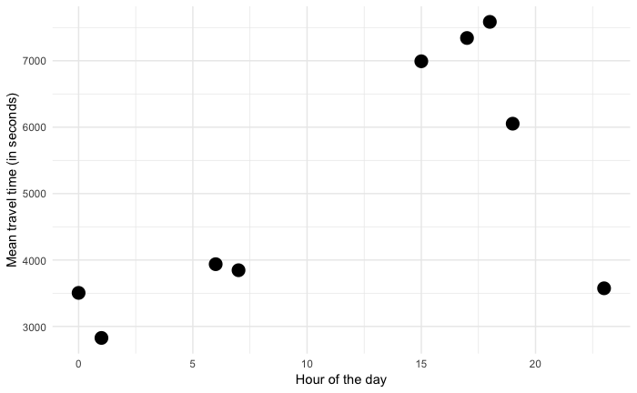

```r
ggplot(data = inter_ward_matrix[inter_ward_matrix$sourceid== 119 & inter_ward_matrix$dstid == 140,], aes(hod,mean_travel_time)) +  geom_point(shape = 16, size = 5) + xlab('Hour of the day') + ylab('Mean travel time (in seconds)') + theme_minimal()
```

- These are longer routes (~25-30 Km’s)
- If you’ll observe the scatter plot, these routes suffer the most between 3 PM till 9 PM
- These routes can be termed as end to end routes, as they start and end mostly at the points which lie on the perimeter of Delhi. Most of these routes start from the Eastern part and end at the Western parts, moving through Central Delhi.

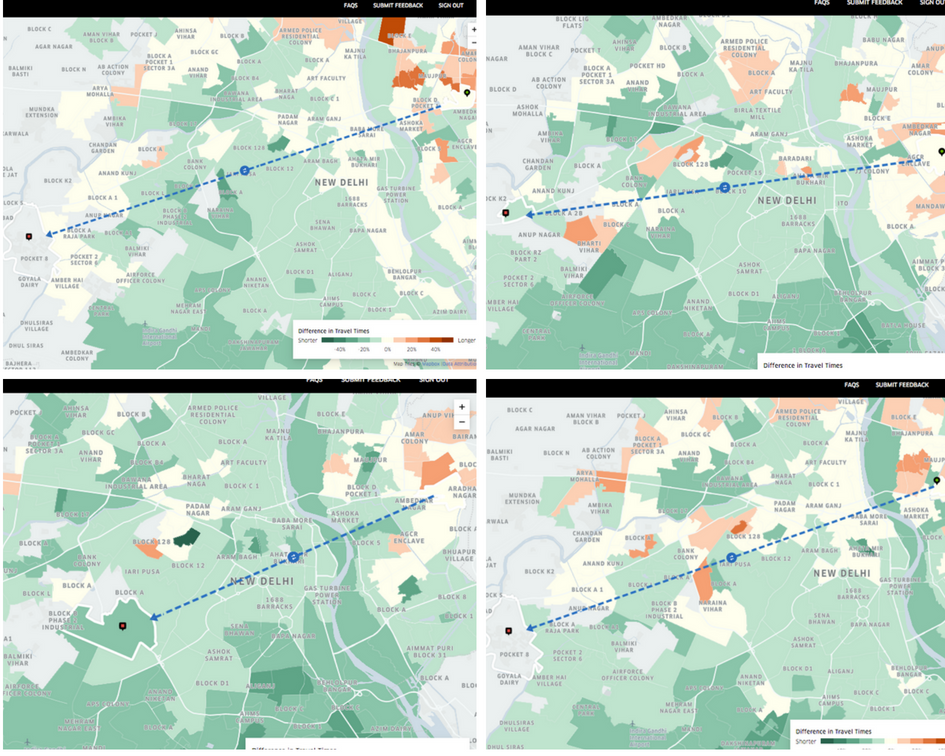